# Appendix to *Measuring Children’s Early Vocabulary in Low-Resource Languages Using a Swadesh-style Word List*

[redacted for anonymous review]

February 1, 2023

## Uni-lemma Overlap on CDI:WS Forms

Number of overlapping concepts on each pair of CDI:WS forms. American English has the highest average degree of overlap (468 uni-lemmas), which may be driven in large part by it being the oldest form, from which many others were adapted. The form with the lowest average degree of overlap is European Spanish, with only 325 uni-lemmas shared with other forms, on average.

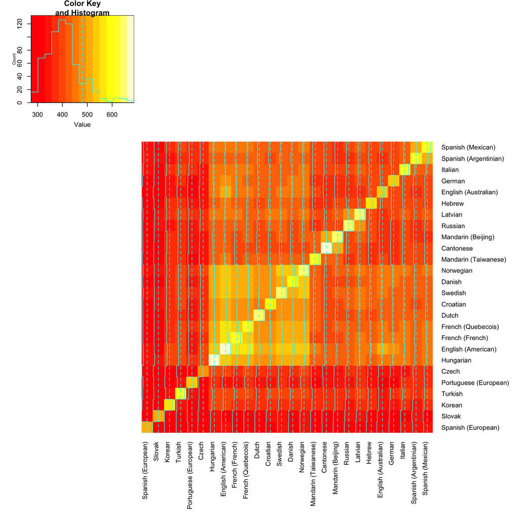

## Word Difficulty by Semantic Category and Language

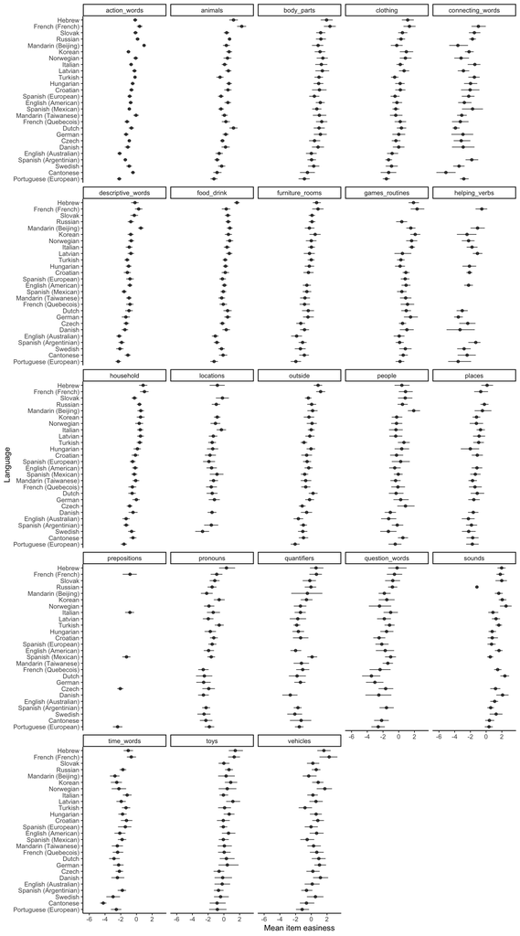

Mean difficulty of CDI words by semantic category and language. Bars represent bootstrapped 95% confidence intervals.

## Cross-linguistic similarities

We look at the Spearman correlation between the item difficulty of each language compared to each other language. We might expect this to recapitulate the historical relationship between languages, with more similar languages having more similar item difficulties (e.g., Quebecois and European French).

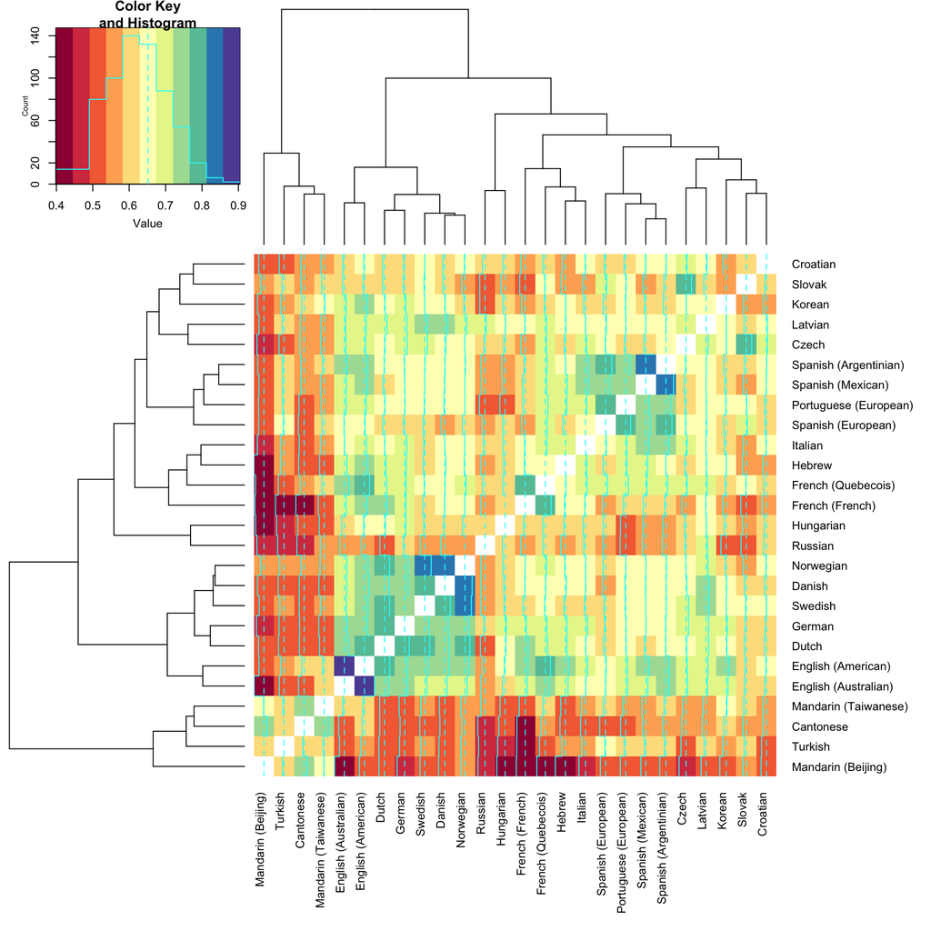

Cross-linguistic similarity (Spearman correlation) of IRT item difficulty from the CDI:WS.

## Evaluating Thresholds for Inclusion on Swadesh CDI

It is unclear how many existing forms a uni-lemma should be included on in order for it to be considered for inclusion on a Swadesh CDI. Instead of setting an arbitrary threshold, we chose to try all possible values of $k$ (i.e., number of forms on which a uni-lemma is included, $k \in \{2,..,26\}$), and chose the $k$ which yields the set of Swadesh CDI (S-CDI) items with the highest total test information. The table below shows test information for each threshold, with the highest S-CDI test information achieved by $k=9$ (66085).

| k | N | Mean d | mean_sd | sd_sd | sd_thresh | S-CDI pool | S-CDI Mean d | S-CDI per form | S-CDI vs CDI:WS | Rand vs CDI:WS | S-CDI Info | Rand Info |
| --- | --- | --- | --- | --- | --- | --- | --- | --- | --- | --- | --- | --- |
| 2 | 1303 | 0.830 | 1.179 | 0.527 | 0.916 | 360 | 1.151 | 91.885 | 0.993 | 0.994 | 33870 | 34186 |
| 3 | 1079 | 0.675 | 1.217 | 0.426 | 1.004 | 327 | 0.906 | 140.308 | 0.996 | 0.997 | 51551 | 52479 |
| 4 | 946 | 0.618 | 1.237 | 0.372 | 1.051 | 303 | 0.786 | 166.538 | 0.996 | 0.997 | 61465 | 62343 |
| 5 | 853 | 0.557 | 1.243 | 0.344 | 1.071 | 282 | 0.627 | 175.577 | 0.996 | 0.997 | 65220 | 65832 |
| 6 | 796 | 0.490 | 1.249 | 0.336 | 1.081 | 261 | 0.524 | 175.154 | 0.996 | 0.997 | 65251 | 65733 |
| 7 | 745 | 0.453 | 1.251 | 0.327 | 1.088 | 245 | 0.495 | 174.962 | 0.996 | 0.997 | 65375 | 65789 |
| 8 | 696 | 0.393 | 1.253 | 0.318 | 1.094 | 232 | 0.378 | 174.962 | 0.996 | 0.997 | 65452 | 65813 |
| 9 | 674 | 0.367 | 1.256 | 0.315 | 1.098 | 229 | 0.330 | 176.423 | 0.996 | 0.997 | 66085 | 66374 |
| 10 | 640 | 0.323 | 1.254 | 0.306 | 1.101 | 217 | 0.258 | 173.115 | 0.996 | 0.997 | 65054 | 65151 |
| 11 | 608 | 0.274 | 1.257 | 0.299 | 1.107 | 204 | 0.183 | 169.654 | 0.996 | 0.997 | 63840 | 63895 |
| 12 | 573 | 0.229 | 1.256 | 0.296 | 1.108 | 194 | 0.132 | 165.538 | 0.996 | 0.997 | 62425 | 62287 |
| 13 | 547 | 0.184 | 1.253 | 0.290 | 1.108 | 186 | 0.072 | 161.654 | 0.995 | 0.997 | 60922 | 60799 |
| 14 | 523 | 0.150 | 1.247 | 0.284 | 1.105 | 179 | 0.041 | 157.577 | 0.995 | 0.997 | 59279 | 59270 |
| 15 | 497 | 0.099 | 1.248 | 0.282 | 1.107 | 170 | -0.033 | 152.231 | 0.995 | 0.997 | 57419 | 57221 |
| 16 | 472 | 0.045 | 1.242 | 0.276 | 1.104 | 163 | -0.089 | 148.077 | 0.995 | 0.997 | 55775 | 55641 |
| 17 | 449 | -0.015 | 1.241 | 0.278 | 1.102 | 155 | -0.117 | 141.923 | 0.994 | 0.997 | 53506 | 53329 |
| 18 | 419 | -0.049 | 1.237 | 0.277 | 1.099 | 144 | -0.199 | 133.731 | 0.994 | 0.996 | 50216 | 50221 |
| 19 | 391 | -0.152 | 1.232 | 0.274 | 1.094 | 134 | -0.296 | 125.769 | 0.993 | 0.996 | 47124 | 47203 |
| 20 | 362 | -0.184 | 1.235 | 0.277 | 1.096 | 126 | -0.336 | 119.385 | 0.993 | 0.996 | 45348 | 44825 |
| 21 | 312 | -0.312 | 1.226 | 0.271 | 1.091 | 105 | -0.504 | 101.346 | 0.991 | 0.995 | 38642 | 37984 |
| 22 | 289 | -0.401 | 1.221 | 0.269 | 1.086 | 97 | -0.607 | 94.154 | 0.990 | 0.994 | 35778 | 35284 |
| 23 | 241 | -0.577 | 1.208 | 0.268 | 1.074 | 81 | -0.741 | 79.808 | 0.989 | 0.993 | 30271 | 29872 |
| 24 | 195 | -0.734 | 1.200 | 0.257 | 1.071 | 66 | -0.880 | 65.923 | 0.987 | 0.992 | 25292 | 24661 |
| 25 | 142 | -1.102 | 1.190 | 0.253 | 1.064 | 46 | -1.278 | 47.000 | 0.979 | 0.988 | 17859 | 17584 |
| 26 | 82 | -1.351 | 1.199 | 0.263 | 1.067 | 28 | -1.372 | 29.385 | 0.969 | 0.981 | 11390 | 10987 |

## Swadesh CDI vs. Full CDI:WS

For the 26 languages that the IRT models were trained on:

Swadesh CDI vs. Full CDI:WS scores for 26 training languages.

| language | N | Rand r | Swadesh r |
| --- | --- | --- | --- |
| Cantonese | 181 | 0.997 | 0.996 |
| Croatian | 187 | 0.996 | 0.992 |
| Czech | 163 | 0.997 | 0.997 |
| Danish | 198 | 0.998 | 0.994 |
| Dutch | 196 | 0.998 | 0.998 |
| English (American) | 201 | 0.998 | 0.996 |
| English (Australian) | 167 | 0.998 | 0.996 |
| French (French) | 196 | 0.998 | 0.996 |
| French (Quebecois) | 192 | 0.997 | 0.996 |
| German | 166 | 0.998 | 0.996 |
| Hebrew | 165 | 0.997 | 0.995 |
| Hungarian | 204 | 0.998 | 0.996 |
| Italian | 167 | 0.997 | 0.994 |
| Korean | 155 | 0.997 | 0.993 |
| Latvian | 180 | 0.998 | 0.996 |
| Mandarin (Beijing) | 165 | 0.998 | 0.997 |
| Mandarin (Taiwanese) | 183 | 0.998 | 0.997 |
| Norwegian | 195 | 0.998 | 0.996 |
| Portuguese (European) | 145 | 0.996 | 0.988 |
| Russian | 176 | 0.997 | 0.996 |
| Slovak | 141 | 0.997 | 0.995 |
| Spanish (Argentinian) | 188 | 0.997 | 0.993 |
| Spanish (European) | 137 | 0.996 | 0.991 |
| Spanish (Mexican) | 191 | 0.998 | 0.994 |
| Swedish | 194 | 0.998 | 0.996 |
| Turkish | 154 | 0.998 | 0.994 |

### Generalization Test

Comparison to the eight low-data languages. Note that many proposed Swadesh items are not actually on the CDI:WS forms available to test generalization.

Swadesh CDI vs. Full CDI:WS scores for 8 generalization languages.

| language | N | Rand r | Swadesh r |
| --- | --- | --- | --- |
| English (Irish) | 161 | 0.995 | 0.990 |
| Finnish | 161 | 0.997 | 0.997 |
| Greek (Cypriot) | 142 | 0.994 | 0.987 |
| Irish | 160 | 0.995 | 0.988 |
| Kigiriama | 179 | 0.996 | 0.996 |
| Kiswahili | 179 | 0.996 | 0.992 |
| Persian | 103 | 0.987 | 0.983 |
| Spanish (Peruvian) | 141 | 0.996 | 0.991 |

## Swadesh-CDI Items

Below we show the full list of 229 Swadesh CDI uni-lemmas, along with their average cross-linguistic difficulty (d_m), variability in difficulty (d_sd), number of CDI:WS forms they appear on (n, out of 26), semantic category, and lexical category. The semantic and lexical categories are based on American English, as uni-lemmas sometimes appear in different categories on different forms, as appropriate.

|  | uni_lemma | d_m | d_sd | n | category | lexical_category |
| --- | --- | --- | --- | --- | --- | --- |
| 1 | fit | 2.38985745894968 | 1.06617513921568 | 9 | action_words | predicates |
| 2 | stay | 1.9544971545335 | 0.783759167492222 | 15 | action_words | predicates |
| 3 | lick | 1.93372308819395 | 0.962544210674131 | 17 | action_words | predicates |
| 4 | hear | 1.24025724522676 | 1.0817168641973 | 21 | action_words | predicates |
| 5 | like | 1.16822204917727 | 1.02332327244765 | 20 | action_words | predicates |
| 6 | sweep | 0.960007004327655 | 1.08341645226747 | 20 | action_words | predicates |
| 7 | swim | 0.940130745267788 | 0.788311562976917 | 23 | action_words | predicates |
| 8 | catch | 0.93876352823625 | 0.936453209903606 | 19 | action_words | predicates |
| 9 | wait | 0.697448288357049 | 0.874394710481381 | 26 | action_words | predicates |
| 10 | knock | 0.588466948570046 | 0.836793370963193 | 12 | action_words | predicates |

[output cut: 219 more lines]

## Guide to Developing a Swadesh-based CDI

Developing a CDI for a new language is a substantial task requiring specific linguistic and cultural knowledge – even with the new Swadesh-CDI recommendations in hand. Many recommendations and caveats have been enumerated by the CDI Advisory Board, here: https://mb-cdi.stanford.edu/adaptations.html Rather than recapitulate the process and caveats already itemized there, we suggest how the Swadesh CDI can be used to jump-start the process.